# Theory

This vignette presents a general overview of the *clugen* algorithm. A complete description of the algorithm’s theoretical framework is available in the article “[Generating multidimensional clusters with support lines](https://doi.org/10.1016/j.knosys.2023.110836)” (an open version is [available on arXiv](https://arxiv.org/abs/2301.10327)).

*Clugen* is an algorithm for generating multidimensional clusters. Each cluster is supported by a line segment, the position, orientation and length of which guide where the respective points are placed. For brevity, *line segments* will be referred to as *lines*.

Given an $n$-dimensional direction vector $\mathbf{d}$ (and a number of additional parameters, which will be discussed shortly), the *clugen* algorithm works as follows ($^*$ means the algorithm step is stochastic):

1. Normalize $\mathbf{d}$.
2. $^*$Determine cluster sizes.
3. $^*$Determine cluster centers.
4. $^*$Determine lengths of cluster-supporting lines.
5. $^*$Determine angles between $\mathbf{d}$ and cluster-supporting lines.
6. For each cluster:
   1. $^*$Determine direction of the cluster-supporting line.
   2. $^*$Determine distance of point projections from the center of the cluster-supporting line.
   3. Determine coordinates of point projections on the cluster-supporting line.
   4. $^*$Determine points from their projections on the cluster-supporting line.

Figure 1 provides a stylized overview of the algorithm’s steps.

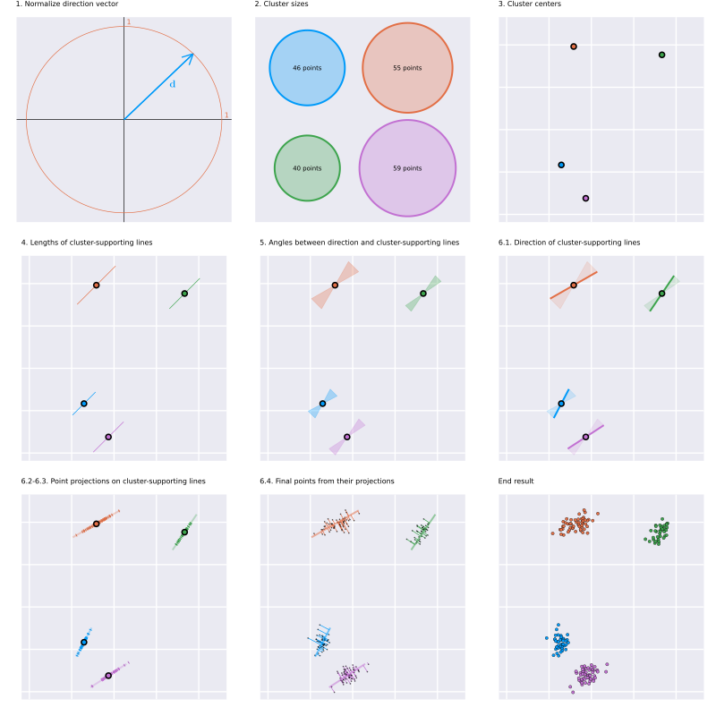

**Figure 1** - Stylized overview of the *clugen* algorithm. Background tiles are 10 units wide and tall, when applicable.

The example in Figure 1 was generated with the following parameters:

| Parameter values | Description |
| --- | --- |
| $n=2$ | Number of dimensions. |
| $c=4$ | Number of clusters. |
| $p=200$ | Total number of points. |
| $\mathbf{d}=\begin{bmatrix}1 & 1\end{bmatrix}^T$ | Average direction. |
| $\theta_\sigma=\pi/16\approx{}11.25^{\circ}$ | Angle dispersion. |
| $\mathbf{s}=\begin{bmatrix}10 & 10\end{bmatrix}^T$ | Average cluster separation. |
| $l=10$ | Average line length. |
| $l_\sigma=1.5$ | Line length dispersion. |
| $f_\sigma=1$ | Cluster lateral dispersion. |

Additionally, all optional parameters (not listed above) were left to their default values. The complete list of parameters is presented in the `clugen()` function documentation.